# Homework 03 - z-scores, data frames, and graphs

**ANSWER:**

# 11. Bonus Learning Time: This is mostly just for learning some new things.

When you used `str()` to see how many levels of `genhlth` there were, you should have discovered the answer. But we can also do this another way, which is very useful as you will see. But first,

11.1. Use `levels()` on your `genhlth` variable to return the level names of `genhlth`

**ANSWER:**

11.2. Use `nlevels()` on your `genhlth` variable to return the number of levels of `genhlth`

**ANSWER:**

11.3. We can use `histogram()` in the lattice library to create some nice graphs. In order to do so, you will have to leverage some of the function arguments that are not needed to create the default graph. For example, you could plot a histogram for weight as a function of `sex` (groups). But there are some special things we need to keep in mind.

- The `~` should precede the variable that you want to plot. There is good reason for this, but we won’t get into the reason why just yet.
- The `|` is used to specify which factor/categorical variable by which to split out your variable.
- So `~X | Race` would mean “Hey, plot the numeric variable X for each level of Race.”

So, using our HEALTH data frame, let’s plot a histogram for weight a each level of `sex`, we would have:

Ex: `with(dataframe, lattice::histogram(~ variable | grouping var))`

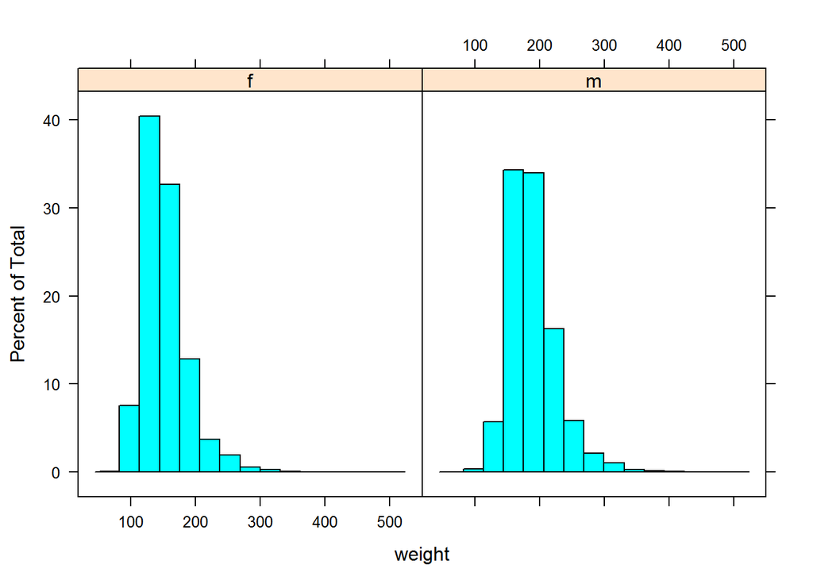

```r
with(HEALTH, lattice::histogram(~weight | sex))
```

```r
# or lattice::histogram(~HEALTH$weight | HEALTH$sex)
```

11.4. **QUESTION:** What is the label on the y-axis?

**ANSWER:**

By default, `histogram()` does not plot frequencies. Rather, the default plot type is in `"percent"` values. The code behind the default would look like that displayed in the code block below. Also, notice that when you add an argument, you need to separate each argument with a comma. If you do not include the comma, `R` with throw an error because you aren’t speaking the language it understands. Remembering that each argument in a function is separated by a comma.

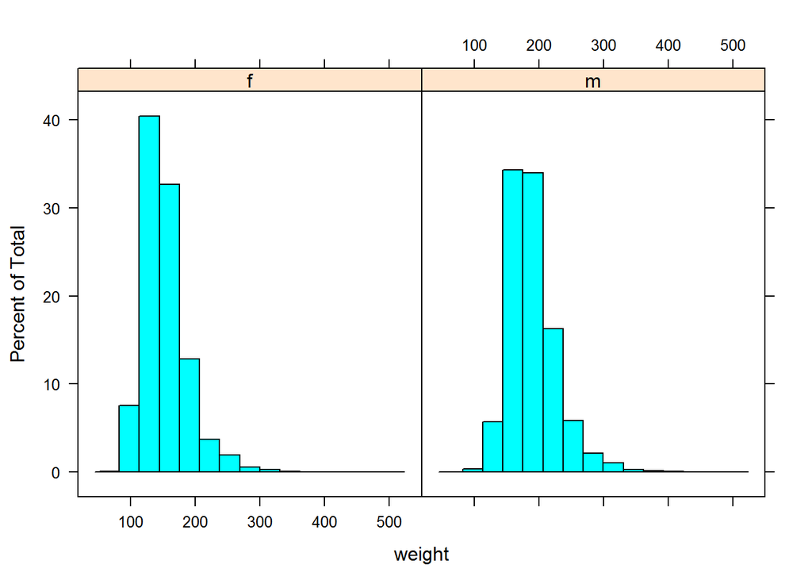

```r
with(HEALTH, lattice::histogram(~weight | sex, type = "percent"))
```

11.5. We can change the `type` argument from `"percent"` to `"count"` by copying the code above and modifying it in the code block below. Remember, all arguments need to be inside the parentheses of `histogram()`; always make sure you enclose your functions in parentheses. Try this yourself.

**ANSWER:**

11.6. **QUESTION:** What is the label on the y-axis of the plot?

**ANSWER:**

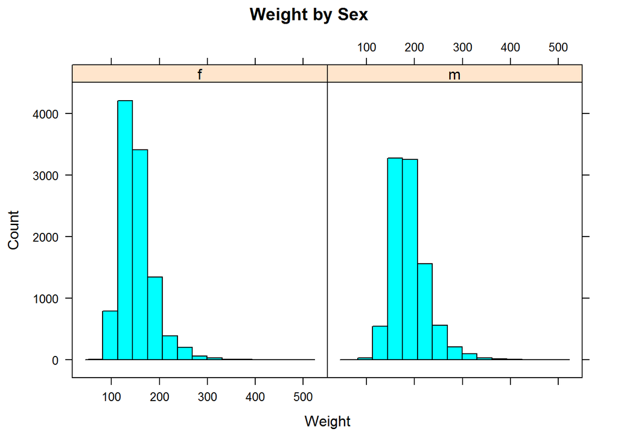

```r
with(HEALTH, lattice::histogram(~weight | sex, type = "count",
          main = "Weight by Sex",
          xlab = "Weight"))
```

11.8. And if you don’t like the side-by-side layout, you can add the `layout` argument to your function. However, you will need to know how many levels there are of your grouping variable. In this example, you would use the number of levels of sex, which is 2. By default, the layout displays the graphs side-by-side. I set `layout = c(1,2)` so that we can see both plots along the same x-axis with one on top of the other.

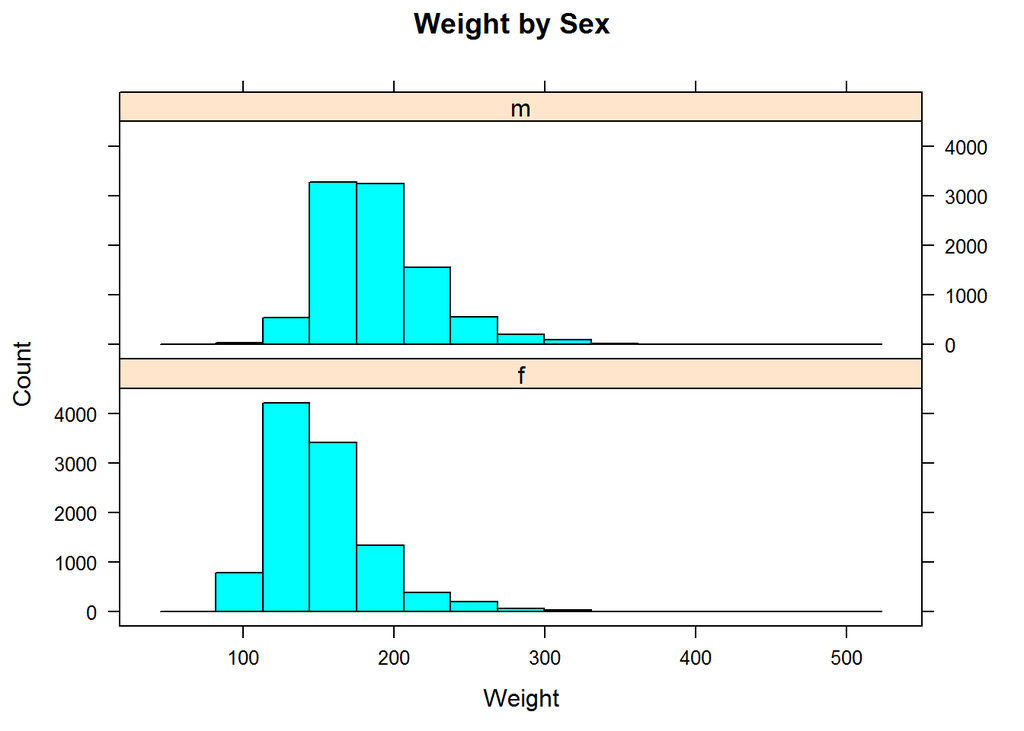

```r
with(HEALTH, lattice::histogram(~weight | sex, type = "count",
          main = "Weight by Sex",
          xlab = "Weight",
          layout = c(1, 2)))
```

11.9. **QUESTION:** Based on your graph, do weights appear greater for men or for women?

**ANSWER:**

11.10. But if we wanted to plot the graphs in a similar way to see groups based on the `genhlth` variable rather than the `sex` variable, you would have to count the levels and change them from 2 to the other value. If you use `nlevels()` as demonstrated above, you can replace 2 with `with(HEALTH, nlevels(genhlth))` and `R` will get the number of levels. Be careful, however, because you are nesting multiple functions inside each other and you need to make sure your parentheses balance out appropriately. If you look carefully, you are nesting `nlevels()` inside `c()` which is inside `histogram()` which is inside `with()`, which gives you 4 sets of parentheses.

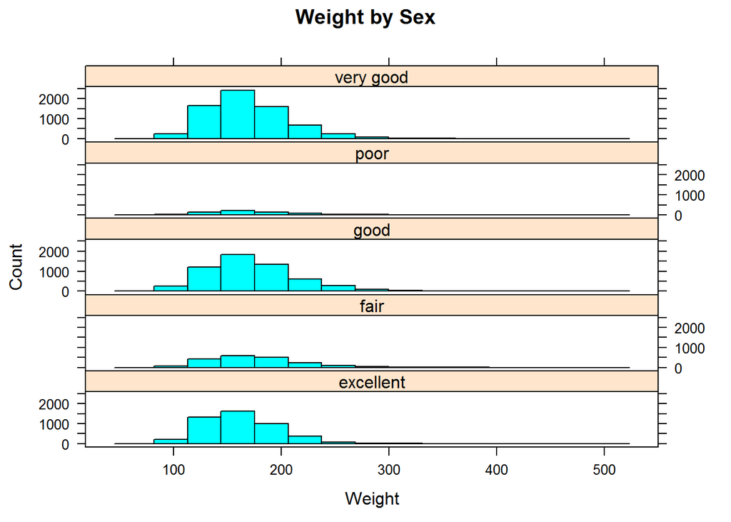

```r
with(HEALTH, lattice::histogram(~weight | genhlth, type = "count",
          main = "Weight by Sex",
          xlab = "Weight",
          layout = c(1, nlevels(genhlth))))
```

11.11. **QUESTION:** But this graph is (probably) not yet perfect unless you change the labels to reflect your new grouping variable. Change the `main` and `xlab` arguments to be correct for the variable you are plotting.

**ANSWER:**

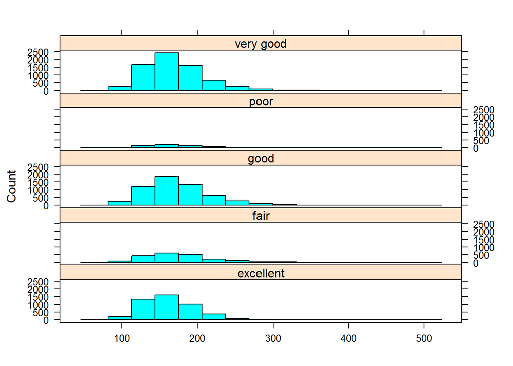

```r
with(HEALTH, lattice::histogram(~weight | genhlth, type = "count",
          main = "",
          xlab = "",
          layout = c(1, nlevels(genhlth))) )
```

For more details on `histogram()` type `?histogram` in the console window below and look at the help window.

## Now save your file and press the knit HTML button on the toolbar to create your HTML file and upload that to the Dropbox folder on Sakai. I hope you had fun!